# Jaselin V S

### Track: Data Analytics

### Task: EDA on Retail Sales Data — Oasis Infobyte SIP

# Exploratory Data Analysis: Retail Sales Data

**Objective:** This notebook performs an exploratory data analysis (EDA) on a global retail sales dataset (2011–2014, 51,290 orders across 21 fields) to identify sales trends, customer behavior patterns, and product/category performance, and to translate these findings into actionable business recommendations.

**Dataset:** Global Superstore sales data, sourced from Kaggle, containing order-level details including sales revenue, quantity, discount, profit, shipping cost, customer segment, geographic region, and product category.

**Approach:** The analysis proceeds through initial data inspection and cleaning, descriptive statistics, time series trend analysis, customer segment and regional breakdowns, product and category performance, and correlation analysis — concluding with a summary of key findings and recommendations.

```python
import pandas as pd
```

```python
df = pd.read_csv('SuperStoreOrders.csv')
```

```python
df.shape
```

```
(51290, 21)
```

```python
df.dtypes
```

```
order_id              str
order_date            str
ship_date             str
ship_mode             str
customer_name         str
segment               str
state                 str
country               str
market                str
region                str
product_id            str
category              str
sub_category          str
product_name          str
sales                 str
quantity            int64
discount          float64
profit            float64
shipping_cost     float64
order_priority        str
year                int64
dtype: object
```

```python
df.isnull().sum()
```

```
order_id          0
order_date        0
ship_date         0
ship_mode         0
customer_name     0
segment           0
state             0
country           0
market            0
region            0
product_id        0
category          0
sub_category      0
product_name      0
sales             0
quantity          0
discount          0
profit            0
shipping_cost     0
order_priority    0
year              0
dtype: int64
```

```python
df['sales'] = df['sales'].astype(str).str.replace(',', '').str.replace('$', '', regex=False)
df['sales'] = df['sales'].astype(float)
```

```python
df['order_date'] = pd.to_datetime(df['order_date'], format='mixed', dayfirst=True)
df['ship_date'] = pd.to_datetime(df['ship_date'], format='mixed', dayfirst=True)
```

```python
df.info()
```

```
<class 'pandas.DataFrame'>
RangeIndex: 51290 entries, 0 to 51289
Data columns (total 21 columns):
 #   Column          Non-Null Count  Dtype
---  ------          --------------  -----
 0   order_id        51290 non-null  str
 1   order_date      51290 non-null  datetime64[us]
 2   ship_date       51290 non-null  datetime64[us]
 3   ship_mode       51290 non-null  str
 4   customer_name   51290 non-null  str
 5   segment         51290 non-null  str
 6   state           51290 non-null  str
 7   country         51290 non-null  str
 8   market          51290 non-null  str
 9   region          51290 non-null  str
 10  product_id      51290 non-null  str
 11  category        51290 non-null  str
 12  sub_category    51290 non-null  str
 13  product_name    51290 non-null  str
 14  sales           51290 non-null  float64
 15  quantity        51290 non-null  int64
 16  discount        51290 non-null  float64
 17  profit          51290 non-null  float64
 18  shipping_cost   51290 non-null  float64
 19  order_priority  51290 non-null  str
 20  year            51290 non-null  int64
dtypes: datetime64[us](2), float64(4), int64(2), str(13)
memory usage: 15.5 MB
```

```python
df['order_date'].dt.year.value_counts().sort_index()
```

```
order_date
2011     8998
2012    10962
2013    13799
2014    17531
Name: count, dtype: int64
```

```python
df[['sales', 'quantity', 'discount', 'profit', 'shipping_cost']].describe()
```

|  | sales | quantity | discount | profit | shipping_cost |
| --- | --- | --- | --- | --- | --- |
| count | 51290.000000 | 51290.000000 | 51290.000000 | 51290.000000 | 51290.000000 |
| mean | 246.498440 | 3.476545 | 0.142908 | 28.641740 | 26.375915 |
| std | 487.567175 | 2.278766 | 0.212280 | 174.424113 | 57.296804 |
| min | 0.000000 | 1.000000 | 0.000000 | -6599.978000 | 0.000000 |
| 25% | 31.000000 | 2.000000 | 0.000000 | 0.000000 | 2.610000 |
| 50% | 85.000000 | 3.000000 | 0.000000 | 9.240000 | 7.790000 |
| 75% | 251.000000 | 5.000000 | 0.200000 | 36.810000 | 24.450000 |
| max | 22638.000000 | 14.000000 | 0.850000 | 8399.976000 | 933.570000 |

```python
df[['sales', 'quantity', 'discount', 'profit', 'shipping_cost']].mode().iloc[0]
```

```
sales            13.00
quantity          2.00
discount          0.00
profit            0.00
shipping_cost     0.86
Name: 0, dtype: float64
```

```python
import matplotlib.pyplot as plt
import seaborn as sns
```

```python
df['order_month'] = df['order_date'].dt.to_period('M')
monthly_sales = df.groupby('order_month')['sales'].sum()
monthly_sales
```

```
order_month
2011-01     98902.0
2011-02     91152.0
2011-03    145726.0
2011-04    116927.0
2011-05    146762.0
2011-06    215214.0
2011-07    115518.0
2011-08    207570.0
2011-09    290230.0
2011-10    199070.0
2011-11    298499.0
2011-12    333941.0
2012-01    135775.0
2012-02    100521.0
2012-03    163092.0
2012-04    161060.0
2012-05    208370.0
2012-06    256181.0
2012-07    145247.0
2012-08    303158.0
2012-09    289390.0
2012-10    252942.0
2012-11    323512.0
2012-12    338245.0
2013-01    199197.0
2013-02    167247.0
2013-03    198591.0
2013-04    177835.0
2013-05    260525.0
2013-06    396513.0
2013-07    229940.0
2013-08    326491.0
2013-09    376626.0
2013-10    293423.0
2013-11    373996.0
2013-12    405476.0
2014-01    241267.0
2014-02    184848.0
2014-03    263110.0
2014-04    242781.0
2014-05    288404.0
2014-06    401843.0
2014-07    258718.0
2014-08    456633.0
2014-09    481186.0
2014-10    422785.0
2014-11    555312.0
2014-12    503154.0
Freq: M, Name: sales, dtype: float64
```

```python
df['order_quarter'] = df['order_date'].dt.to_period('Q')
quarterly_sales = df.groupby('order_quarter')['sales'].sum()
quarterly_sales
```

```
order_quarter
2011Q1     335780.0
2011Q2     478903.0
2011Q3     613318.0
2011Q4     831510.0
2012Q1     399388.0
2012Q2     625611.0
2012Q3     737795.0
2012Q4     914699.0
2013Q1     565035.0
2013Q2     834873.0
2013Q3     933057.0
2013Q4    1072895.0
2014Q1     689225.0
2014Q2     933028.0
2014Q3    1196537.0
2014Q4    1481251.0
Freq: Q-DEC, Name: sales, dtype: float64
```

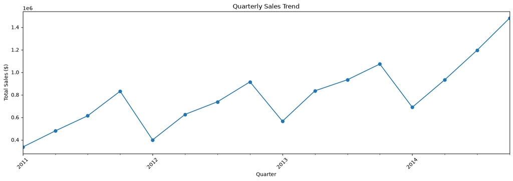

```python
plt.figure(figsize=(14, 5))
quarterly_sales.plot(kind='line', marker='o')
plt.title('Quarterly Sales Trend')
plt.xlabel('Quarter')
plt.ylabel('Total Sales ($)')
plt.xticks(rotation=45)
plt.tight_layout()
plt.show()
```

Quarterly Sales Trend Observations The quarterly view confirms the seasonal pattern seen in the monthly data: Q4 (Oct-Dec) is consistently the strongest quarter each year, while Q1 (Jan-Mar) is consistently the weakest. Despite this recurring dip, each year's Q1 outperforms the previous year's Q1, confirming steady overall business growth from 2011 to 2014.

```python
df.columns.tolist()
```

```
['order_id',
 'order_date',
 'ship_date',
 'ship_mode',
 'customer_name',
 'segment',
 'state',
 'country',
 'market',
 'region',
 'product_id',
 'category',
 'sub_category',
 'product_name',
 'sales',
 'quantity',
 'discount',
 'profit',
 'shipping_cost',
 'order_priority',
 'year',
 'order_month',
 'order_quarter']
```

```python
segment_counts = df['segment'].value_counts()
segment_counts
```

```
segment
Consumer       26518
Corporate      15429
Home Office     9343
Name: count, dtype: int64
```

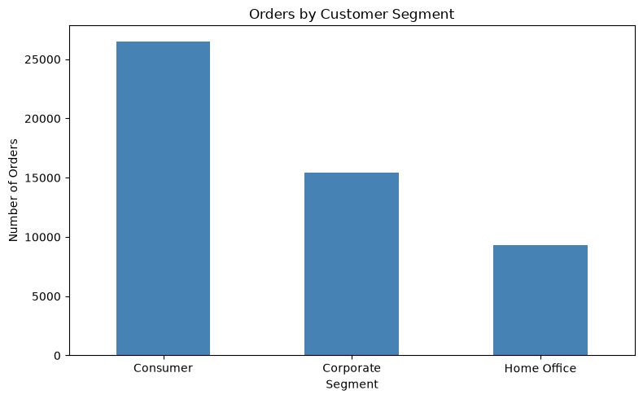

```python
plt.figure(figsize=(8, 5))
segment_counts.plot(kind='bar', color='steelblue')
plt.title('Orders by Customer Segment')
plt.xlabel('Segment')
plt.ylabel('Number of Orders')
plt.xticks(rotation=0)
plt.tight_layout()
plt.show()
```

```python
segment_sales = df.groupby('segment')['sales'].sum().sort_values(ascending=False)
segment_sales
```

```
segment
Consumer       6508141.0
Corporate      3824808.0
Home Office    2309956.0
Name: sales, dtype: float64
```

Customer Segment Observations The Consumer segment generates the most total revenue ($6.51M) and has by far the highest order count (26,518), while Corporate ($3.82M, 15,429 orders) and Home Office ($2.31M, 9,343 orders) trail behind. However, average order value is nearly identical across all three segments (~$245-248), showing that Consumer's revenue lead comes from order volume, not higher per-order spending — a useful distinction for targeting strategy.

```python
region_sales = df.groupby('region')['sales'].sum().sort_values(ascending=False)
region_sales
```

```
region
Central           2822399.0
South             1600960.0
North             1248192.0
Oceania           1100207.0
Southeast Asia     884438.0
North Asia         848349.0
EMEA               806184.0
Africa             783776.0
Central Asia       752839.0
West               725514.0
East               678834.0
Caribbean          324281.0
Canada              66932.0
Name: sales, dtype: float64
```

Regional Sales Observations The Central region generates by far the most revenue ($2.82M), roughly 76% more than the second-highest region (South, $1.60M). Revenue drops off sharply toward smaller regions like Caribbean and Canada, with Canada generating the least by a wide margin ($67K) — a potential area to investigate further (e.g., market size, distribution reach, or expansion opportunity).

```python
top_products = df.groupby('product_name')['sales'].sum().sort_values(ascending=False).head(10)
top_products
```

```
product_name
Apple Smart Phone, Full Size                                86936.0
Cisco Smart Phone, Full Size                                76441.0
Motorola Smart Phone, Full Size                             73159.0
Nokia Smart Phone, Full Size                                71904.0
Canon imageCLASS 2200 Advanced Copier                       61600.0
Hon Executive Leather Armchair, Adjustable                  58200.0
Office Star Executive Leather Armchair, Adjustable          50667.0
Harbour Creations Executive Leather Armchair, Adjustable    50120.0
Samsung Smart Phone, Cordless                               48654.0
Nokia Smart Phone, with Caller ID                           47880.0
Name: sales, dtype: float64
```

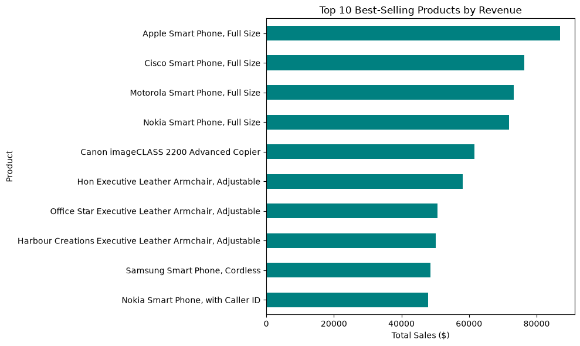

```python
plt.figure(figsize=(10, 6))
top_products.sort_values().plot(kind='barh', color='teal')
plt.title('Top 10 Best-Selling Products by Revenue')
plt.xlabel('Total Sales ($)')
plt.ylabel('Product')
plt.tight_layout()
plt.show()
```

```python
category_sales = df.groupby('category')['sales'].sum().sort_values(ascending=False)
category_sales
```

```
category
Technology         4744691.0
Furniture          4110884.0
Office Supplies    3787330.0
Name: sales, dtype: float64
```

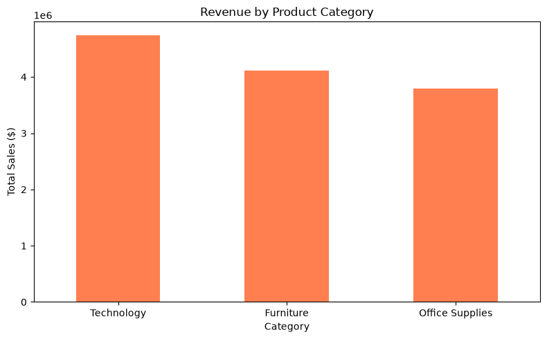

```python
plt.figure(figsize=(8, 5))
category_sales.plot(kind='bar', color='coral')
plt.title('Revenue by Product Category')
plt.xlabel('Category')
plt.ylabel('Total Sales ($)')
plt.xticks(rotation=0)
plt.tight_layout()
plt.show()
```

Product & Category Observations The top 10 best-selling products are dominated by two product types across multiple brands: smartphones (6 of 10 entries) and executive leather office chairs (3 of 10 entries), suggesting these are strong-performing product categories rather than isolated hits. This is confirmed at the category level: Technology leads overall revenue ($4.74M), closely followed by Furniture ($4.11M) and Office Supplies ($3.79M) — all three categories contribute fairly evenly, with no single category dominating the business.

```python
numeric_cols = ['sales', 'quantity', 'discount', 'profit', 'shipping_cost']
corr_matrix = df[numeric_cols].corr()
corr_matrix
```

|  | sales | quantity | discount | profit | shipping_cost |
| --- | --- | --- | --- | --- | --- |
| sales | 1.000000 | 0.313580 | -0.086728 | 0.485944 | 0.768075 |
| quantity | 0.313580 | 1.000000 | -0.019875 | 0.104743 | 0.272649 |
| discount | -0.086728 | -0.019875 | 1.000000 | -0.316375 | -0.079056 |
| profit | 0.485944 | 0.104743 | -0.316375 | 1.000000 | 0.357033 |
| shipping_cost | 0.768075 | 0.272649 | -0.079056 | 0.357033 | 1.000000 |

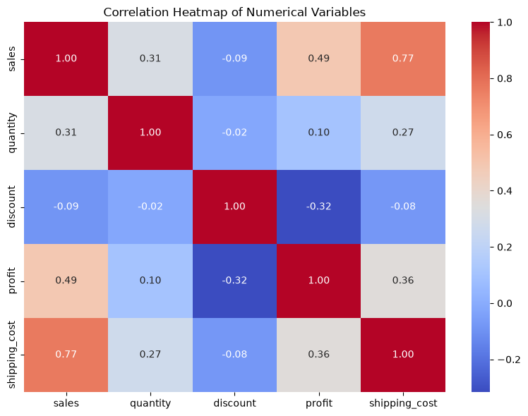

```python
plt.figure(figsize=(8, 6))
sns.heatmap(corr_matrix, annot=True, cmap='coolwarm', fmt='.2f')
plt.title('Correlation Heatmap of Numerical Variables')
plt.tight_layout()
plt.show()
```

```python
category_discount_profit = df.groupby('category')[['discount', 'profit']].mean()
category_discount_profit
```

| category | discount | profit |
| --- | --- | --- |
| Furniture | 0.168087 | 29.038300 |
| Office Supplies | 0.137409 | 16.578961 |
| Technology | 0.135342 | 65.454958 |

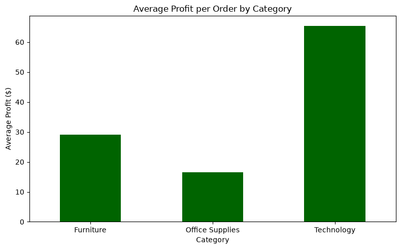

```python
plt.figure(figsize=(8, 5))
category_discount_profit['profit'].plot(kind='bar', color='darkgreen')
plt.title('Average Profit per Order by Category')
plt.xlabel('Category')
plt.ylabel('Average Profit ($)')
plt.xticks(rotation=0)
plt.tight_layout()
plt.show()
```

Non-Obvious Insight: Discount vs. Profitability by Category Furniture receives the highest average discount (16.8%) of any category, yet earns the second-lowest average profit per order ($29.04) — despite being a top-revenue category. Technology, by contrast, receives the lightest discounting (13.5%) and earns by far the highest average profit per order ($65.45). This suggests Furniture's heavy discounting may be substantially suppressing profitability that its strong revenue performance would otherwise support — a strong candidate for a pricing/discount policy review.

## Conclusion & Business Recommendations

This analysis examined 51,290 retail orders spanning 2011–2014 across customer segments, regions, product categories, and time. Below is a summary of key findings and actionable recommendations based on the data.

### Key Findings

- **Consistent growth**: Revenue grew year-over-year from 2011 to 2014, with a strong seasonal pattern — Q4 (Oct–Dec) is consistently the strongest period, while Q1 (Jan–Mar) is consistently the weakest.
- **Consumer segment leads on volume, not value**: The Consumer segment drives the most total revenue, but this is due to a higher number of orders — average order value is nearly identical (~$245–248) across Consumer, Corporate, and Home Office segments.
- **Central region is the strongest market**, generating significantly more revenue than any other region, while regions like Canada remain minimal contributors.
- **Discounting hurts profitability**: Higher discounts are moderately correlated with lower profit (-0.32). Furniture is the most heavily discounted category (16.8% average) and earns the lowest average profit per order relative to its revenue, while Technology — the least discounted category — earns the highest average profit per order.

### Recommendations

**1. Reassess Furniture's discounting strategy.** Furniture generates strong revenue but is undermined by heavy average discounting (16.8%), resulting in comparatively weak per-order profit. Reducing discount depth on Furniture — or restricting deep discounts to slow-moving inventory only — could meaningfully improve profitability without necessarily sacrificing revenue.

**4. Protect and grow the Technology category.** Technology is the most profitable category per order and receives the lightest discounting, indicating healthy underlying demand. Prioritizing marketing spend and inventory investment here is likely to yield strong returns compared to categories requiring heavier discounts to move.